# Lab1CP1

Maiana Brito

30 de outubro de 2017

## Introdução

Neste checkpoint utilizarei os dados disponibilizados na atividade, estes dados apresentam dados referentes ao uso do CEAP(cota para o exercício da atividade parlamentar) pelos deputados, informando a cada despesa o valor da mesma, o tipo, nome do deputado como o partido e estado do mesmo.

### 1. Quais os partidos que mais fazem uso da CEAP? Quais os partidos que menos fazem uso? Mesmas perguntas considerando valores em R$.

Para uma melhor visualização a seguir estão gráficos de barra, o primeiro com os partidos e gastos de cada e o segundo com os partidos e a frequência do uso do CEAP.

[interactive chart not shown]

A partir do gráfico podemos perceber que os partidos que mais gastam são o PMDB(R$ 71502438.62), PT( R$ 67878749.33), PSDB (R$ 52649824.02).

[interactive chart not shown]

Já a partir do segundo gráfico notamos que os partidos que mais fazem uso do CEAP são PT que teve frequência de 129587, já o PMDB 112875x e PSDB 98241x.

### 2. Quais os tipos de despesa mais comuns no uso da CEAP? Mesma pergunta considerando valores em R$.

[interactive chart not shown]

Para responder essa pergunta escolhi o gráfico de barras novamente. Com relação à despesa mais frequente é possível ver que são **Emissão Bilhete Aéreo(300.185x), Combustíveis e lubrificantes(196.858x) e Telefonia(89.322)**, já as despesas que tiveram maior gasto foram **Divulgação da atividade parlamentar(R$ 136.771.779,62), Emissão Bilhete Aéreo(R$ 131.029.914,23), Locação ou fretamento de veículos automotores(R$ 131.029.914,23)**.

### 3.Levando em conta o estado pelo qual o deputado se elegeu, quais os estados que mais fazem uso da CEAP? Quais os que menos fazem uso? Mesmas perguntas considerando gastos em R$. Por que você acha isso?

[interactive chart not shown]

Os estados que mais fazem uso do CEAP e gastam mais são SP e MG, enquanto DF e AP são os que menos fazem uso, já os estados que menos gastam são DF e MT. Acredito que os valores encontrados para ambos os casos(gasto e frequencia de uso) está relacionado com a quantidade de deputados de cada estado.

### 4. Quais os parlamentares que mais gastam com CEAP e quais os que menos gastam?

[interactive chart not shown]

No gráfico 1 estão o nome dos 6 deputados que menos gastaram já no Gráfico 2 estão os deputados que mais gastaram.

### 5. Existe correlação entre a quantidade de gastos no exterior e o valor restituído da CEAP?

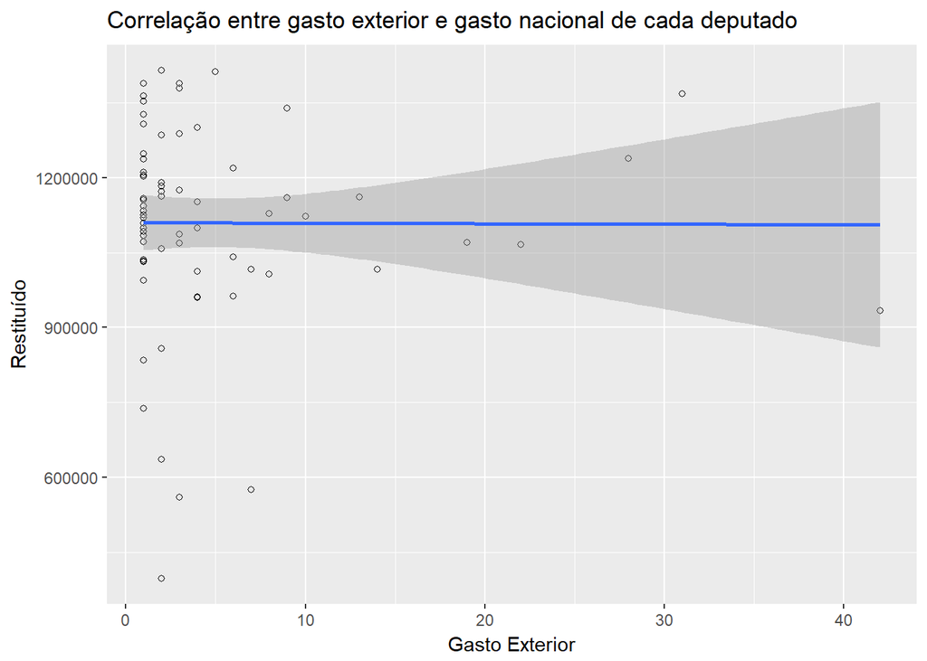

Para responder essa pergunta eu agrupei os dados em relação ao parlamentar e vi se existia a correlação entre o **valor líquido total** de cota que o deputado recebeu e a **quantidade** de gastos que o mesmo teve com gastos no Exterior, para esse caso encontrei correlação quase nula, valor aproximado de *-0,0038..*, como esse valor é próximo de zero pode-se dizer que **não apresenta correçalão**.